# Rapport de projet, IF36

### Exploration de l’effet de la nature de la famille (monoparentale, biparentale) sur la santé des élèves.

L’hypothèse naturelle qu’on emmettrait est que le fait de vivre dans une famille où les parents sont séparés aurait un effet négatif sur la santé. Seulement, lorsqu’on s’intéresse à la moyenne de l’état de santé dans les deux cas, on obtient des résultats assez similaires.

```r
data1 <- dfMaths %>% select(Pstatus, health) %>%
  group_by(Pstatus) %>%
  summarise_all(funs(mean))
```

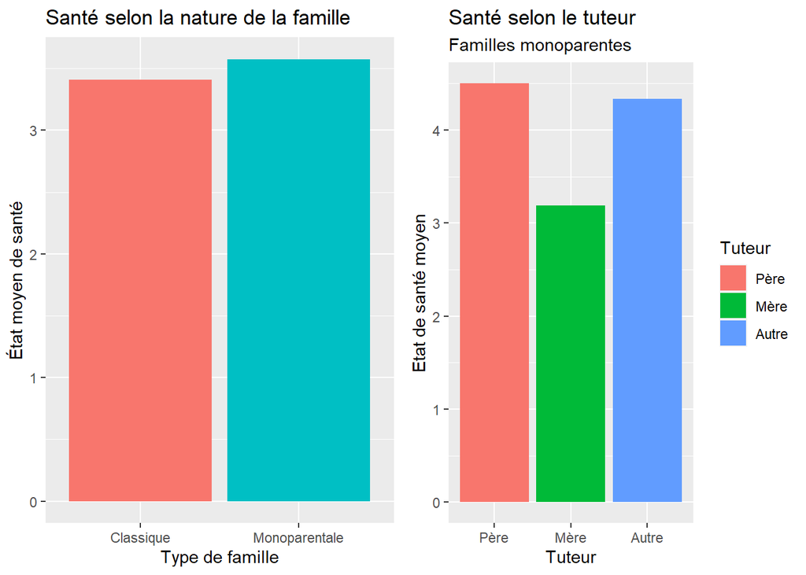

```r
plot1 <- ggplot(data1, aes(x = factor(Pstatus), y = health, fill = Pstatus )) +
  geom_col() +
  labs( title = "Santé selon la nature de la famille", x = "Type de famille", y =  "État moyen de santé") +
  scale_fill_discrete(name = "Type de famille", labels = c("A : Classique", " T : Monoparentale")) +
  scale_x_discrete(labels  = c("Classique", "Monoparentale") ) +
  theme(legend.position = "none")

data2 <- dfMaths %>% filter(Pstatus == 'A') %>%
  select(guardian, health) %>%
  group_by(guardian) %>%
  summarise_all(funs(mean))

plot2 <- ggplot(data2, aes(x = factor(guardian), y = health, fill = guardian )) +
  geom_col() +
  labs( title = "Santé selon le tuteur",
        subtitle = "Familles monoparentes",
        x = "Tuteur", y = "Etat de santé moyen",
        fill = "guardian") +
  scale_fill_discrete(name = "Tuteur", labels = c("Père", "Mère","Autre")) +
  scale_x_discrete(labels  = c("Père", "Mère","Autre") )

grid.arrange(plot1, plot2, nrow = 1)
```

Cependant, lorsqu’on rentre dans le détail de chaque catégorie et qu’on s’intéresse aux tuteurs, on se rend compte que les élèves éduqués par une mère seule ont plus de soucis de santé, décrochant de près d’un point des autres cas.

Pour essayer d’expliquer cela, nous avons essayé de faire une étude sur l’emploi et l’éducation de ces femmes seules à s’occuper de leurs enfants. On pourrait imaginer qu’elles n’occupent pas des métiers à haut revenu ou qu’elles n’ont pas faites de longues études.

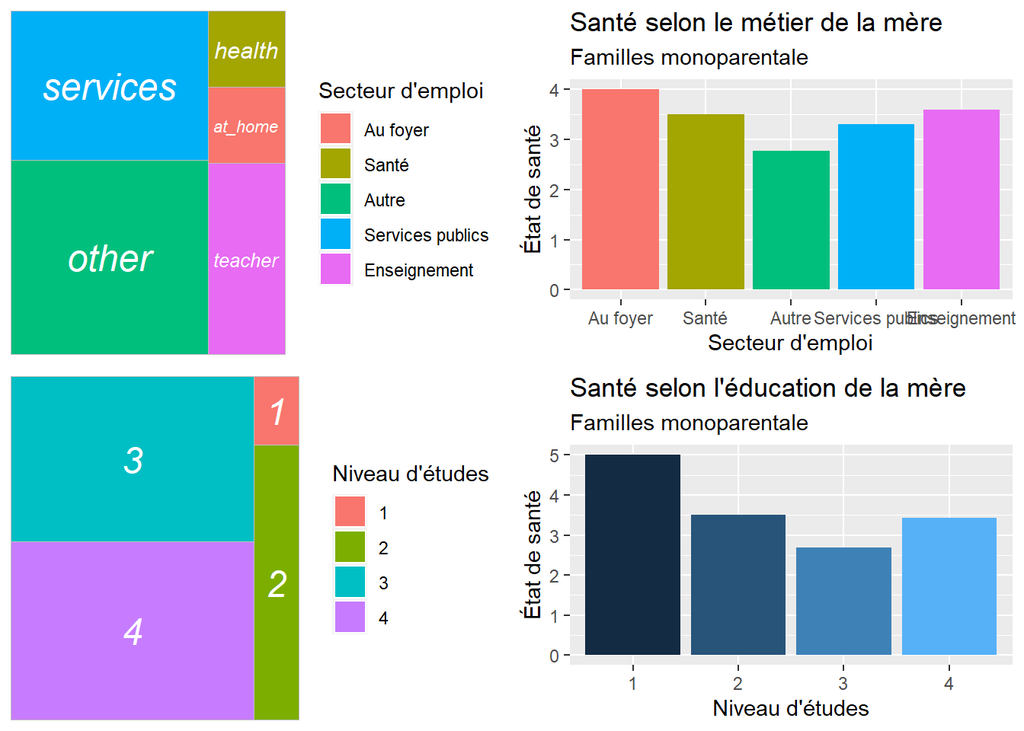

```r
data1 <- dfMaths %>% filter(Pstatus == 'A', guardian == "mother") %>%
  select(Mjob) %>% count(Mjob)

data2 <- data <- dfMaths %>% filter(Pstatus == 'A', guardian == "mother") %>%
  select(Mjob, health) %>%
  group_by(Mjob) %>%
  summarise_all(funs(mean))

data3 <- dfMaths %>% filter(Pstatus == 'A', guardian == "mother") %>%
  select(Medu) %>% count(Medu)

data4 <- data <- dfMaths %>% filter(Pstatus == 'A', guardian == "mother") %>%
  select(Medu, health) %>%
  group_by(Medu) %>%
  summarise_all(funs(mean))

plot1 <- ggplot(data1, aes(area = n, fill = Mjob, label = Mjob)) +
  geom_treemap() +
  geom_treemap_text(fontface = "italic", colour = "white", place = "centre") +
  scale_fill_discrete(name = "Secteur d'emploi", labels = c("Au foyer", "Santé","Autre","Services publics", "Enseignement"))



plot2 <- ggplot(data2, aes(x = factor(Mjob) , y = health, fill = Mjob)) +
  geom_col() +
  labs(title = "Santé selon le métier de la mère",
       subtitle = "Familles monoparentale",
       x = "Travail de la mère",
       y = "État de santé") +
  theme(legend.position = "none") +
  scale_x_discrete(name = "Secteur d'emploi", labels = c("Au foyer", "Santé","Autre","Services publics", "Enseignement"))

plot3 <- ggplot(data3, aes(area = n, fill = factor(Medu), label = Medu)) +
  geom_treemap() +
  geom_treemap_text(fontface = "italic", colour = "white", place = "centre") +
  scale_fill_discrete(name = "Niveau d'études", labels = c("1", "2","3","4"))

plot4 <- ggplot(data4, aes(x = factor(Medu) , y = health, fill = Medu)) +
  geom_col() +
  labs(title = "Santé selon l'éducation de la mère",
       subtitle = "Familles monoparentale",
       x = "Éducation de la mère",
       y = "État de santé") +
  scale_x_discrete(name = "Niveau d'études", labels = c("1", "2","3","4")) +
  theme(legend.position = "none")

grid.arrange(plot1, plot2, plot3, plot4, nrow = 2, ncol = 2)
```

In fine, on ne peut confirmer que la moitié de nos hypothèses. Pour ce qui est de l’emploi de la mère, celles exerçant des activités autres que dans les services publics, la santé et l’enseignement, qui sont aussi les plus nombreuses sont celles pour lesquelles on retrouve les moins bons états de santé chez les enfants. En ce qui concerne le niveau d’éducation, on agréablement surpris de voir que les mères ayant les plus bas niveaux d’éducation s’en sortent le mieux.

### Etat de santé selon la relation famlliale

Nous partons sur l’idée selon laquelle de mauvaises relations familiales ont des répercutions négatives sur la santé des élèves

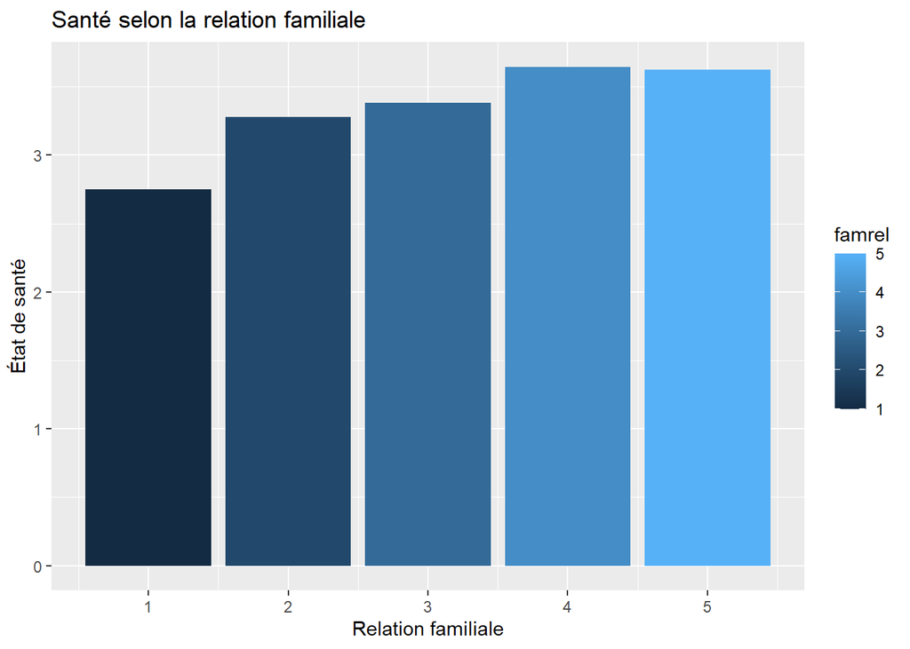

```r
data <- dfMaths %>% select(health, famrel) %>%
  group_by(famrel) %>% summarise_all(funs(mean))

plot <- data %>% ggplot( aes(x = famrel, y = health)) +
  geom_col(aes( fill = famrel)) +
  labs( title = "Santé selon la relation familiale",
        x = "Relation familiale", y = "État de santé")
plot
```

En effet, nous voyons clairement une évolution progressive de la santé suivant la qualité de la relation familiale

### Etat de santé en fonction du travail des parents

Les systèmes de santé étant assez bien développés en Europe en général, nous ne nous attendons pas à avoir des différences significatives selon le métier des parents.

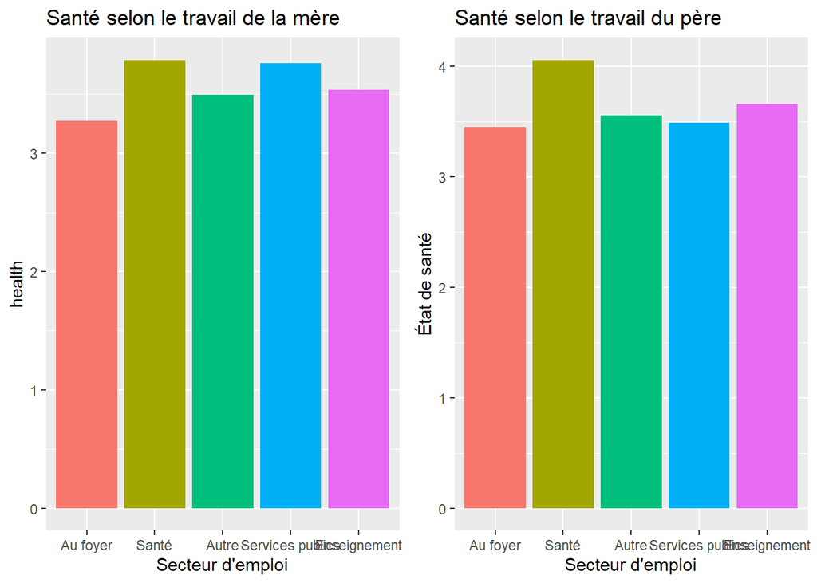

```r
data1 <- dfMaths %>% select(Mjob, health) %>%
  group_by(Mjob) %>%
  summarise_all(funs(mean))

plot1 <- ggplot(data1, aes( x = factor(Mjob), y = health, fill = Mjob)) +
  geom_col() +
  labs(title = "Santé selon le travail de la mère") +
  scale_x_discrete(name = "Secteur d'emploi", labels = c("Au foyer", "Santé","Autre","Services publics", "Enseignement"))+
  theme(legend.position = "none")

data2 <- dfMaths %>% select(Fjob, health) %>%
  group_by(Fjob) %>%
  summarise_all(funs(mean))

plot2 <- ggplot(data2, aes( x = factor(Fjob), y = health, fill = Fjob)) +
  geom_col() +
  labs(title = "Santé selon le travail du père",
       y = "État de santé") +
  scale_x_discrete(name = "Secteur d'emploi", labels = c("Au foyer", "Santé","Autre","Services publics", "Enseignement"))+
  theme(legend.position = "none")

grid.arrange(plot1, plot2, nrow = 1)
```

Effectivement, nous n’observons pas de gros écarts mais nous remarquons tout de même que les parenrs travaillant dans le secteur de la santé ont les enfants présentant les meilleurs résultats sur cet aspect

### Etat de santé en fonction de l’éducation des parents

Ici on peut faire l’hypothèse selon laquelle le fait d’avoir des parents de faible niveau d’éducation aurait des effets néfastes sur la santé des élèves.

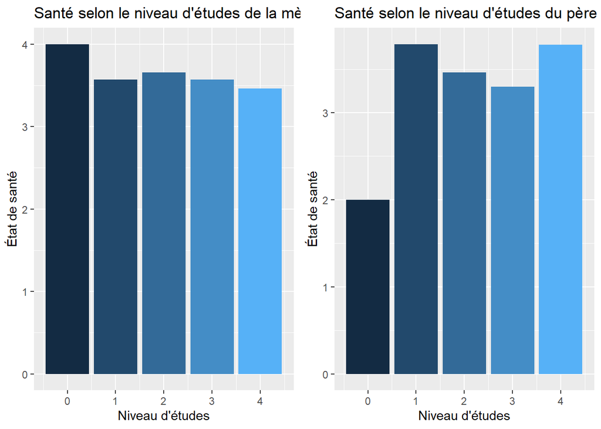

```r
data1 <- dfMaths %>% select(Medu, health) %>%
  group_by(Medu) %>%
  summarise_all(funs(mean))

plot1 <- ggplot(data1, aes( x = Medu, y = health, fill = Medu)) +
  geom_col() +
  labs(title = "Santé selon le niveau d'études de la mère",
       x = "Niveau d'études",
       y = "État de santé") +
  theme(legend.position = "none")

data2 <- dfMaths %>% select(Fedu, health) %>%
  group_by(Fedu) %>%
  summarise_all(funs(mean))

plot2 <- ggplot(data2, aes( x = Fedu, y = health, fill = Fedu)) +
  geom_col() +
  labs(title = "Santé selon le niveau d'études du père",
       x = "Niveau d'études",
       y = "État de santé") +
  theme(legend.position = "none")

grid.arrange(plot1, plot2, nrow = 1)
```

On se rend compte après étude que l’hypothèse n’est pas complètement vérifiée et on observe des comportements différents selon le sexe du parent. Alors que la santé des enfants de mères ayant le plus bas niveau d’études est la meilleur, celle des pères ayant le plus bas niveau d’études est de façon significative moins bonne que celle des autres.